# Temporal Analysis

How delays distribute across time dimensions: hour of day, weekday, month, season and full year.

## Setup

```python
from zh_tram_flow.notebook import *
import zh_tram_flow.analytics.temporal as an

TRAIN, TEST, lf, lf_all, lf_delay, lf_clean = setup_analysis("03_analysis_3-temporal")

# lf_all   — train + test features combined (all years)
# lf_delay — lf_all filtered: canceled == False
# lf_clean — analysis-ready: canceled=False · stop_sequence>1 · no Linie E/L50/L51
#             departure_delay / delay_delta masked to NaN for Nov 14–Dec 23 2025
#             (is_anomal flag added for transparency)
%load_ext autoreload
%autoreload 2
```

```
✓  wgnd theme activated (matplotlib · seaborn)
```

```
2026-06-11 11:22:54  INFO      project  03_analysis_3-temporal started
```

```
The autoreload extension is already loaded. To reload it, use:
  %reload_ext autoreload
```

## Hour of Day

Ø `arrival_delay` pro Stunde — Rush-Hour-Muster und Nachtbetrieb. Rechts: Volumen zeigt wann die Daten dünn werden.

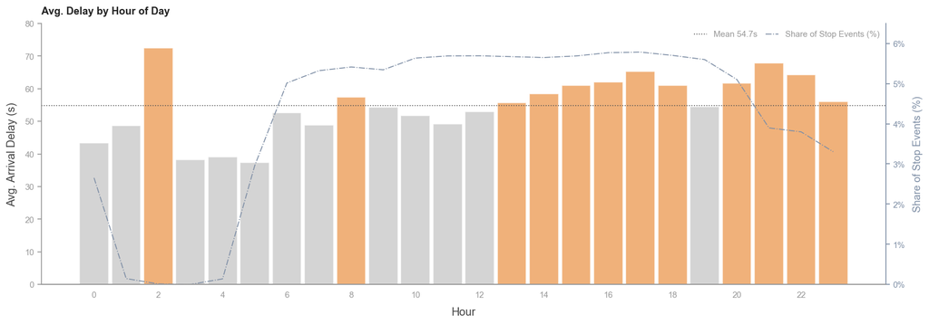

| Hour | Avg. Delay (s) | Median (s) | N Halte |
| --- | --- | --- | --- |
| 0 | 43.40 | 30.00 | 2,380,420 |
| 1 | 48.70 | 24.00 | 130,756 |
| 2 | 72.50 | 42.00 | 11,548 |
| 3 | 38.20 | 33.00 | 478 |
| 4 | 39.00 | 26.00 | 124,412 |
| 5 | 37.30 | 30.00 | 2,653,855 |
| 6 | 52.60 | 42.00 | 4,499,518 |
| 7 | 48.90 | 37.00 | 4,775,364 |
| 8 | 57.30 | 43.00 | 4,857,369 |
| 9 | 54.30 | 42.00 | 4,794,902 |
| 10 | 51.70 | 40.00 | 5,056,915 |
| 11 | 49.20 | 39.00 | 5,104,253 |
| 12 | 52.90 | 41.00 | 5,107,887 |
| 13 | 55.60 | 44.00 | 5,088,320 |
| 14 | 58.40 | 45.00 | 5,069,149 |
| 15 | 61.00 | 46.00 | 5,103,969 |
| 16 | 62.00 | 44.00 | 5,177,057 |
| 17 | 65.20 | 46.00 | 5,190,288 |
| 18 | 61.00 | 42.00 | 5,116,269 |
| 19 | 54.50 | 40.00 | 5,023,008 |
| 20 | 61.70 | 47.00 | 4,579,297 |
| 21 | 67.90 | 52.00 | 3,496,721 |
| 22 | 64.20 | 49.00 | 3,408,425 |
| 23 | 56.00 | 42.00 | 2,964,721 |

```python
an.plot_hour_of_day(lf_delay, cfg, ylim=(0,80), ylim_volume=(0, 6.5))

show_df(an.table_hour_of_day(lf_delay))
```

**Beobachtung:** Das Tagesrhythmus-Chart zeigt ein überraschendes Muster: Kein klassischer symmetrischer Doppel-Peak (Morgen/Abend), sondern ein **asymmetrisches Anstiegsprofil mit drei identifizierbaren Nutzungstypen**.

**Ø Delay nach Tageszeit (Ø gesamt ≈55s):**

[output not shown]

**Drei Nutzungstypen im Tagesgang:**

→ `hour` als Feature; Interaktion `hour × has_event` für den 21h-Effekt; `hour × is_weekend` für den 2h-Nachteffekt.

## Day of Week

Average delay per weekday (0=Mon … 6=Sun) — weekend vs weekday patterns.

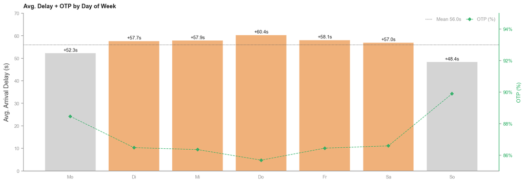

| Weekday | Avg. Delay (s) | Median (s) | P95 (s) | N Halte |
| --- | --- | --- | --- | --- |
| Mo | 52.30 | 40.00 | 172.00 | 13,620,317 |
| Di | 57.70 | 44.00 | 186.00 | 13,485,124 |
| Mi | 57.90 | 44.00 | 186.00 | 13,522,020 |
| Do | 60.40 | 45.00 | 194.00 | 13,372,724 |
| Fr | 58.10 | 44.00 | 187.00 | 13,288,211 |
| Sa | 57.00 | 42.00 | 189.00 | 12,684,117 |
| So | 48.40 | 38.00 | 160.00 | 9,742,388 |

```python
an.plot_day_of_week(lf_delay, cfg, ylim=(0, 70), ylim_otp=(85, 95))
show_df(an.table_day_of_week(lf_delay))
```

**Beobachtung:** **Donnerstag zeigt die höchste durchschnittliche Verspätung** — nicht Freitag, wie man erwarten könnte.

**Ø Delay und P95 nach Wochentag:**

| Tag | Ø Delay (s) | P95 (s) |
| --- | --- | --- |
| Mo | 52.3 | 172 |
| Di | 57.7 | 186 |
| Mi | 57.9 | 186 |
| **Do** | **60.4** | **194** |
| Fr | 58.1 | 187 |
| Sa | 57.0 | 189 |
| So | 48.4 | 160 |

**Donnerstag ist auf beiden Metriken Spitze** — sowohl im Ø als auch bei P95 (schlechteste 5%). Mo und So sind die besten Tage.

**Warum Donnerstag?** Zwei plausible Erklärungen:

1. **Events-Effekt**: Donnerstag ist in Zürich ein starker Kultur- und Ausgeh-Abend (Konzerte, Messen, Konferenzen). Ein Teil dieser Events fällt gehäuft auf Donnerstage.
2. **Homeoffice-Hypothese**: Wenn Montag und Freitag die häufigsten HO-Tage sind, konzentriert sich Pendlerverkehr auf Di–Do mit Donnerstag als Spitze — plausibel, aber nicht direkt durch VBZ-Daten belegt.

**Wochenende:** Samstag (57.0s) liegt nur leicht unter Werktagsniveau. Sonntag (48.4s) ist deutlich besser — weniger Berufsverkehr und reduzierter Takt im Gleichgewicht. Montag (52.3s) überraschend niedrig — konsistent mit HO-Hypothese.

→ `weekday` als Feature; Interaktion `weekday × hour` prüfen (Donnerstag-Abend-Block).

## Month

Monthly delay averages — seasonal drift visible at month level.

[figure not shown]

| year Month | 2023 | 2024 | 2025 | Ø gesamt |
| --- | --- | --- | --- | --- |
| Jan | 49.40 | 52.40 | 49.60 | 50.60 |
| Feb | 48.60 | 53.10 | 48.50 | 50.00 |
| Mär | 53.60 | 60.60 | 53.80 | 56.00 |
| Apr | 50.80 | 56.30 | 54.50 | 53.90 |
| Mai | 52.60 | 60.30 | 57.20 | 56.70 |
| Jun | 57.50 | 60.50 | 59.20 | 59.10 |
| Jul | 52.70 | 54.50 | 58.60 | 55.30 |
| Aug | 53.20 | 58.30 | 53.40 | 54.90 |
| Sep | 58.50 | 60.10 | 55.20 | 57.70 |
| Okt | 61.20 | 57.70 | 60.50 | 59.80 |
| Nov | 68.90 | 72.60 | 70.70 | 66.10 |
| Dez | 63.20 | 57.80 | nan | 54.40 |

```python
an.plot_day_of_week(lf_delay, cfg, ylim=(0,70), ylim_otp=(85,91))

show_df(an.table_month_seasonality(lf_delay))
```

**Beobachtung:** Klare **November-Peak-Anomalie** bestätigt: November ist in beiden vollständigen Jahren der Jahreshöchstwert — November 2023=68.9s, November 2024=72.6s. Im Jahresvergleich sehen die Kurvenformen ähnlich aus (gleiche saisonale Struktur), aber 2024 liegt in fast allen Monaten über 2023.

**Monatlicher Ø Delay (bereinigt, Nov/Dez 2025 als Artefakt ausgeschlossen):**

[output not shown]

**Warum November?** Kombination aus mehreren Faktoren:

- Herbstlaub auf Gleisen (Leaf Fall Problem): nasses Laub reduziert Haftung, langsamere Einfahrten
- Ende des Herbst-Baustellen-Zyklus: VBZ/Stadt schliessen Gleisbaustellen typischerweise vor Winterfahrplan ab
- Maximale Systembelastung: Schuljahr läuft, kein Ferieneffekt, Dunkelheit und Regen erhöhen MIV-Anteil

> **Juli 2025 — Ausreißer im Sommertal:** Juli 2025 (58.6s) liegt +6.0s über Juli 2023 (52.7s) und +4.1s über Juli 2024 (54.5s). In allen anderen Sommermonaten zeigt 2025 keine vergleichbare Abweichung. Mögliche Ursache: VBZ-Baustellenaktivität im Vorfeld des Fahrplanwechsels Dezember 2025 (Tramnetz Süd). **Status: offen** — prüfen ob dieser Monat als Trainings-Ausreißer behandelt werden sollte.

## Season

Delay by season (1=Winter 2=Spring 3=Summer 4=Fall) — weather and daylight effects.

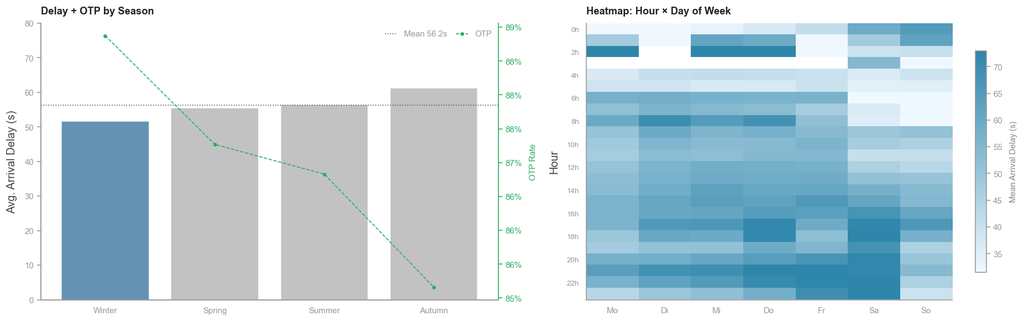

| Season | Avg. Delay (s) | OTP | N Halte |
| --- | --- | --- | --- |
| Winter | 51.70 | 88.9% | 22,134,996 |
| Spring | 55.60 | 87.3% | 22,311,790 |
| Summer | 56.40 | 86.8% | 22,521,041 |
| Autumn | 61.20 | 85.2% | 22,747,074 |

```python
an.plot_season_heatmap(lf_delay, cfg, ylim_season=(0, 80))

show_df(an.table_season(lf_delay))
```

**Beobachtung:** Die Saisonauswertung bestätigt das Muster aus der Monatsanalyse.

**Saisonaler Ø Delay und OTP:**

| Jahreszeit | Ø Delay (s) | OTP |
| --- | --- | --- |
| Winter | **51.7** | **88.9%** |
| Frühling | 55.6 | 87.3% |
| Sommer | 56.4 | 86.8% |
| **Herbst** | **61.2** | **85.2%** |

**Herbst** ist die eindeutig schlechteste Jahreszeit (61.2s, OTP 85.2%). **Winter** ist überraschenderweise die beste — Ø 9.5s unter Herbst. Mögliche Erklärung: Im Winter reduziert sich der MIV-Anteil (Menschen meiden Autofahren bei Schnee/Eis), was die Strassenkonflikte für Trams verringert und den Effekt von Schnee/Eis auf die Gleise teilweise kompensiert. Frühling und Sommer liegen nah beieinander (55.6 vs. 56.4s).

→ `season`, `hour`, `weekday` als Features; Interaktion `hour × weekday` als kombiniertes Feature prüfen.

## Full Year

Weekly or monthly rolling delay trend across all three years — long-term drift and anomalies.

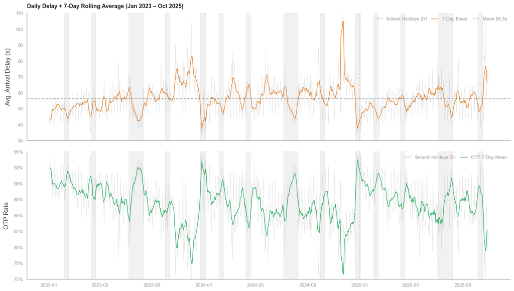

| year Month | 2023 | 2024 | 2025 |
| --- | --- | --- | --- |
| Jan | 48.80 | 51.90 | 49.30 |
| Feb | 48.30 | 52.90 | 48.00 |
| Mär | 53.30 | 60.20 | 53.30 |
| Apr | 50.30 | 56.30 | 54.10 |
| Mai | 52.30 | 59.90 | 56.40 |
| Jun | 57.40 | 60.10 | 58.80 |
| Jul | 52.40 | 54.20 | 58.30 |
| Aug | 52.90 | 57.70 | 53.00 |
| Sep | 58.40 | 59.80 | 55.90 |
| Okt | 60.80 | 57.20 | 60.10 |
| Nov | 67.90 | 72.90 | nan |
| Dez | 63.00 | 57.70 | nan |

```python
an.plot_full_year_trend(lf_delay, cfg, ylim_delay=(30, 110), ylim_otp=(0.75, 0.95))

show_df(an.table_full_year_monthly(lf_delay))
```

**Beobachtung:** Der Rolling-Average-Chart macht die Netzstruktur über alle drei Jahre sichtbar.

**Schulferien-Effekt:** Die grau hinterlegten Schulferienperioden fallen konsistent mit Verspätungs-Tälern zusammen — besonders deutlich bei Sommer- und Herbstferien. Das ist visuell überzeugend: Weniger Schülerverkehr = weniger Trams übervoll = weniger Verzögerungen beim Boarding.

**Strukturelle Befunde:**

- 2024 liegt im Frühling/Sommer **+4–7s** über dem 2023-Niveau — struktureller Anstieg
- 2025 (Jan–Okt) zeigt leichte Stabilisierung gegenüber 2024 — kein weiterer Anstieg
- **Aufwärtstrend moderat:** Das Netz wird nicht dramatisch schlechter, aber liegt strukturell über dem OTP-Sollwert
- November-Peaks in beiden Jahren deutlich sichtbar (→ F-TEMP-05)
- Fahrplanwechsel Dez 2023 (j23→j24): kein scharfer Knick erkennbar — Übergang fliessend

**Einordnung Aufwärtstrend:**

> 2025 war leicht besser als 2024 — das schwächt eine „alarmierenden Trend"-Story. Seriösere Aussage: Das VBZ-Netz läuft stabil nahe seinem OTP-Ziel, hat aber **keinen strukturellen Puffer** bei Sonderereignissen (Schnee, Grossevents, November). Der Schulferien-Dip zeigt: bei reduziertem Druck funktioniert das Netz gut.

## Feature: `gtfs_year`

Netzwerk-Epoche als Feature: `j23` (vor Fahrplanwechsel Dez 2023) vs. `j24_j25` (nach Umbau der Linien 9, 11, 13). Zeigt ob der Strukturbruch in der Zeitreihe einen Sprung erzeugt oder ob die Verspätung kontinuierlich verläuft (F-NET-01, F-NET-03).

```
gtfs_year aus Feature-File geladen
```

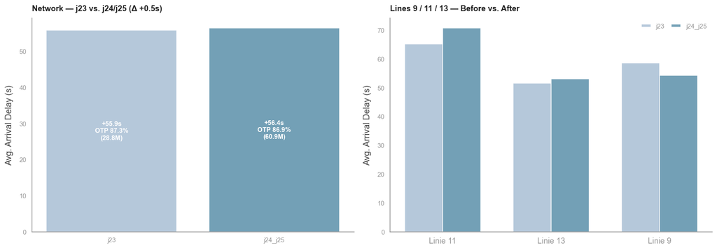

```
gtfs_year Vergleich:
  j23: Ø +55.9s  OTP 87.3%  (28.8M Halte)  [2023-01-01 00:00:00 – 2023-12-31 00:00:00]
  j24_j25: Ø +56.4s  OTP 86.9%  (60.9M Halte)  [2024-01-01 00:00:00 – 2025-12-31 00:00:00]
```

| GTFS-Epoche | Avg. Delay (s) | Median (s) | OTP | N Halte | Von | Bis |
| --- | --- | --- | --- | --- | --- | --- |
| j23 | 55.90 | 43.00 | 87.3% | 28,824,219 | 2023-01-01 00:00:00 | 2023-12-31 00:00:00 |
| j24_j25 | 56.40 | 42.00 | 86.9% | 60,890,682 | 2024-01-01 00:00:00 | 2025-12-31 00:00:00 |

```python
an.plot_gtfs_year_comparison(lf_delay, cfg)

show_df(an.table_gtfs_year_comparison(lf_delay))
```

**Beobachtung:** Der `gtfs_year`-Vergleich zeigt einen **minimal kleinen Netzeffekt**: Netzweit steigt der Ø Delay von j23 auf j24_j25 um nur **+0.5s** (55.9s → 56.4s). Die OTP-Differenz beträgt −0.4pp (87.3% → 86.9%).

**Netzweit: j23 vs. j24_j25:**

| GTFS-Epoche | Ø Delay (s) | OTP | N Halte |
| --- | --- | --- | --- |
| j23 | 55.9 | 87.3% | 28.8M |
| j24_j25 | 56.4 | 86.9% | 60.9M |
| **Δ** | **+0.5s** | **−0.4pp** |  |

**Umgebaute Linien 9, 11, 13 — Vor/Nach:**

| Linie | j23 (s) | j24_j25 (s) | Δ |
| --- | --- | --- | --- |
| L11 | 65.1 | 70.6 | **+5.5s** |
| L13 | 51.6 | 53.1 | +1.5s |
| L9 | 58.6 | 54.3 | **−4.3s** |

**Kernbefund:** Das `gtfs_year`-Feature erklärt netzweit fast nichts (+0.5s). Auf Linie-Ebene gibt es Unterschiede, aber sie zeigen keine einheitliche Richtung: L11 verschlechtert sich, L9 verbessert sich deutlich. Das ist konsistent mit dem Befund aus dem Network-Notebook (F-NET-04, F-NET-05): der Fahrplanwechsel Dez 2023 ist im Delay-Signal nicht als Bruchpunkt erkennbar.

**Implikation für Modellierung:** `gtfs_year` dürfte im Modell schwachen Beitrag leisten — eher als Zeitvariable denn als Netzstruktur-Feature. `n_stops_line` als kontinuierliche Alternative bleibt prüfenswert (F-NET-03). Der strukturelle j23→j24-Anstieg im Rolling-Average erklärt sich besser durch Saisonalität und Jahrestrend als durch den Netzwechsel.

## Key Findings

→ Vollständige Findings-Tabelle mit Impact und Action in `03_analysis_0-overview.ipynb`.

[output not shown]